신록예찬's 블로그

# (노트) Barplot, 해들리위컴의 그래프레이어 문법, 심슨의 역설

Nov 1, 2021 • 최규빈 • 9 min read

시각화

- import
- Barplot
  - 기본사용법 (stat)
  - barplot이 불편한점1
  - barplot이 불편한점2
  - position 조정
  - coord_filp()
  - facet_wrap()
- 해들리위컴의 그래프레이어
- 예제: 심슨의 역설
  - 시각화1: 전체합격률을 barplot으로 시각화하라.
  - 시각화2: 학과별비교
- join 벼락치기

### import

```python
import pandas as pd
import numpy as np
from plotnine import *
import matplotlib.pyplot as plt
```

### Barplot

#### 기본사용법 (stat)

```python
g=['A']*100+['B']*200
y=list(np.random.randn(100)*2+2)+list(np.random.randn(200)+3)
df=pd.DataFrame({'g':g,'y':y})
df
```

|  | g | y |
| --- | --- | --- |
| 0 | A | 0.398934 |
| 1 | A | 2.126768 |
| 2 | A | 3.201686 |
| 3 | A | 4.281099 |
| 4 | A | 3.159682 |
| ... | ... | ... |
| 295 | B | 2.652960 |
| 296 | B | 3.524339 |
| 297 | B | 2.224875 |
| 298 | B | 2.676209 |
| 299 | B | 3.303336 |

300 rows × 2 columns

```python
ggplot(df)+geom_bar(aes(x='g',fill='g')) ## 디폴트로 카운트를 수행해줌
```

`-` 이것은 아래의 코드와 같다.

```python
df.groupby('g').count().reset_index()
```

|  | g | y |
| --- | --- | --- |
| 0 | A | 100 |
| 1 | B | 200 |

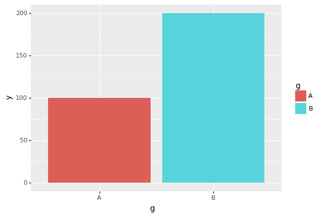

```python
ggplot(df.groupby('g').count().reset_index())+geom_bar(aes(x='g',y='y',fill='g'),stat='identity')
```

`-` barplot은 기본적으로 groupby+count() 가 내장되어있다. 따라서 아래의 코드를 엄밀하게 쓰면

```python
ggplot(df)+geom_bar(aes(x='g',fill='g'))
```

아래와 같다.

```python
ggplot(df)+geom_bar(aes(x='g',fill='g'),stat='count')
```

`-` 이것은 때때로 불편하다. (요건 제 생각이에요)

- 데이터프레임 변환은 판다스를 이용하는게 더 쉽고 자유롭다.

#### barplot이 불편한점1

```python
tb=df.groupby('g').count().reset_index()
tb
```

|  | g | y |
| --- | --- | --- |
| 0 | A | 100 |
| 1 | B | 200 |

`-` 그냥 x='g', y='y'를 맵핑해서 그리면되지 않나?

```
<BarContainer object of 2 artists>
```

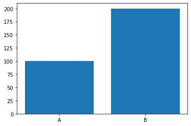

```python
plt.bar(tb.g,tb.y)
```

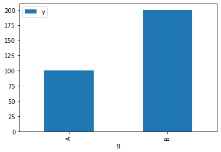

```python
tb.plot(kind='bar',x='g',y='y')
```

`-` 그런데 ggplot을 쓰려고하면?

```python
ggplot(df.groupby('g').count().reset_index())+geom_bar(aes(x='g',y='y',fill='g'))
```

[output not shown]

[output cut: 46 more lines]

[output not shown]

- 불편해요..

#### barplot이 불편한점2

`-` group_by를 자동으로 해주므로 익숙해지면 더 편하지 않을까? $\to$ group_by()를 그냥 하는게 편해요

```python
df.groupby('g').agg({'y':[np.mean,np.median,np.std,lambda x: np.max(x)-np.min(x)]})
```

| g | y mean | y median | y std | y <lambda_0> |
| --- | --- | --- | --- | --- |
| A | 2.075306 | 1.993642 | 2.204191 | 11.382623 |
| B | 3.068608 | 3.109049 | 0.921619 | 5.108941 |

```python
df.groupby('g').agg({'y':[np.mean,np.median,np.std,lambda x: np.max(x)-np.min(x)]}).rename(columns={'<lambda_0>':'range'})
```

| g | y mean | y median | y std | y range |
| --- | --- | --- | --- | --- |
| A | 2.075306 | 1.993642 | 2.204191 | 11.382623 |
| B | 3.068608 | 3.109049 | 0.921619 | 5.108941 |

```python
df.groupby('g').agg({'y':[np.mean,np.median,np.std,lambda x: np.max(x)-np.min(x)]}).rename(columns={'<lambda_0>':'range'}).unstack()
```

```
           g
y  mean    A     2.075306
           B     3.068608
   median  A     1.993642
           B     3.109049
   std     A     2.204191
           B     0.921619
   range   A    11.382623
           B     5.108941
dtype: float64
```

```python
df.groupby('g').agg({'y':[np.mean,np.median,np.std,lambda x: np.max(x)-np.min(x)]}).rename(columns={'<lambda_0>':'range'}).unstack().reset_index()
```

|  | level_0 | level_1 | g | 0 |
| --- | --- | --- | --- | --- |
| 0 | y | mean | A | 2.075306 |
| 1 | y | mean | B | 3.068608 |
| 2 | y | median | A | 1.993642 |
| 3 | y | median | B | 3.109049 |
| 4 | y | std | A | 2.204191 |
| 5 | y | std | B | 0.921619 |
| 6 | y | range | A | 11.382623 |
| 7 | y | range | B | 5.108941 |

```python
df.groupby('g').agg({'y':[np.mean,np.median,np.std,lambda x: np.max(x)-np.min(x)]}).rename(columns={'<lambda_0>':'range'}).unstack().reset_index().rename(columns={0:'value'})
```

|  | level_0 | level_1 | g | value |
| --- | --- | --- | --- | --- |
| 0 | y | mean | A | 2.075306 |
| 1 | y | mean | B | 3.068608 |
| 2 | y | median | A | 1.993642 |
| 3 | y | median | B | 3.109049 |
| 4 | y | std | A | 2.204191 |
| 5 | y | std | B | 0.921619 |
| 6 | y | range | A | 11.382623 |
| 7 | y | range | B | 5.108941 |

```python
fig=ggplot(df.groupby('g').agg({'y':[np.mean,np.median,np.std,lambda x: np.max(x)-np.min(x)]}).rename(columns={'<lambda_0>':'range'}).unstack().reset_index().rename(columns={0:'value'}))
```

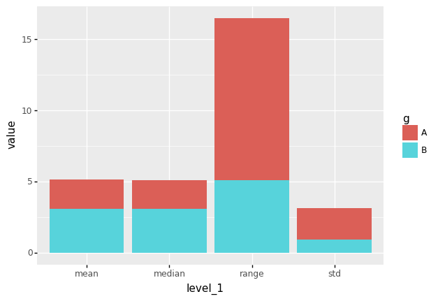

```python
bar1=geom_bar(aes(x='level_1',y='value',fill='g'),stat='identity')
fig+bar1
```

- 쌓아져서 보이는것이 불편해요..

#### position 조정

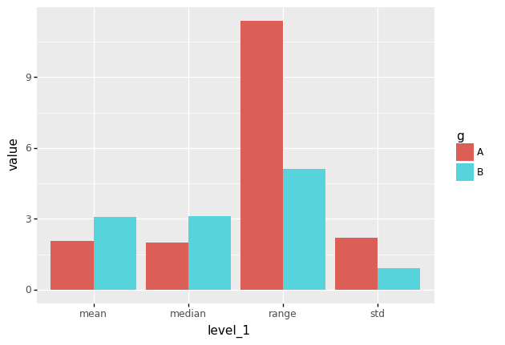

```python
fig+geom_bar(aes(x='level_1',y='value',fill='g'),stat='identity',position='dodge')
```

#### coord_filp()

`-` 때때로 아래와 같이 보는것이 더 좋을 경우도 있음.

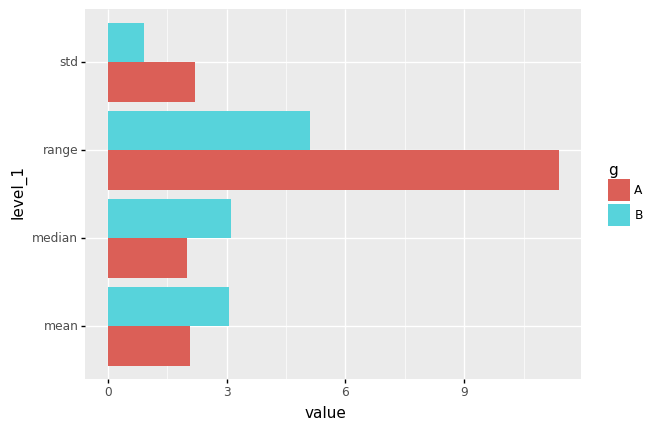

```python
fig+geom_bar(aes(x='level_1',y='value',fill='g'),stat='identity',position='dodge')+coord_flip()
```

#### facet_wrap()

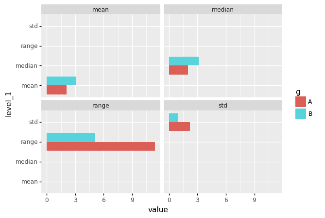

```python
fig+geom_bar(aes(x='level_1',y='value',fill='g'),stat='identity',position='dodge')+coord_flip()+facet_wrap('level_1')
```

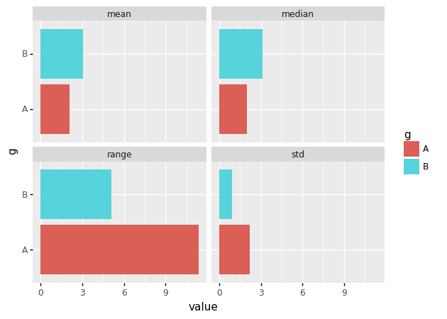

```python
fig+geom_bar(aes(x='g',y='value',fill='g'),stat='identity',position='dodge')+coord_flip()+facet_wrap('level_1')
```

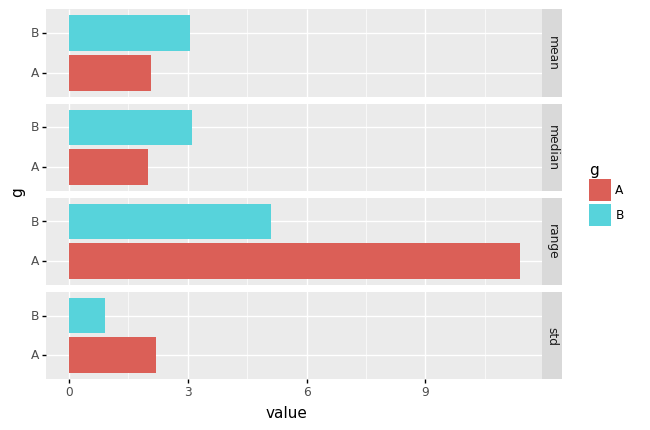

```python
fig+geom_bar(aes(x='g',y='value',fill='g'),stat='identity',position='dodge')+coord_flip()+facet_grid('level_1~')
```

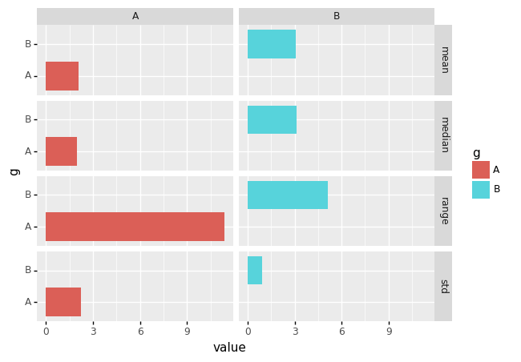

```python
fig+geom_bar(aes(x='g',y='value',fill='g'),stat='identity',position='dodge')+coord_flip()+facet_grid('level_1~g')
```

### 해들리위컴의 그래프레이어

`-` 데이터셋 + 맵핑 + 지옴 + 포지션 + 스탯 + 축 + 면분할

- 데이터셋: 판다스
- 맵핑: x축, y축, 색깔, 크기, 투명도
- 지옴: 포인트지옴, 바지옴, 라인지옴, 스무스지옴
- 포지션: jitter, dodge, indentity
- 스탯: identity, count
- 축: coord_flip()
- 패싯: facet_wrap(), facet_grid()

### 예제: 심슨의 역설

```python
DEP=(['A1']*2+['A2']*2+['B1']*2+['B2']*2)*2
GEN=['M']*8+['F']*8
STATE=['PASS','FAIL']*8
COUNT=[1,9,2,8,80,20,85,15,5,5,5,5,9,1,9,1]
```

```python
df=pd.DataFrame({'DEP':DEP,'STATE':STATE,'GEN':GEN,'COUNT':COUNT})
```

```python
df
```

|  | DEP | STATE | GEN | COUNT |
| --- | --- | --- | --- | --- |
| 0 | A1 | PASS | M | 1 |
| 1 | A1 | FAIL | M | 9 |
| 2 | A2 | PASS | M | 2 |
| 3 | A2 | FAIL | M | 8 |
| 4 | B1 | PASS | M | 80 |
| 5 | B1 | FAIL | M | 20 |
| 6 | B2 | PASS | M | 85 |
| 7 | B2 | FAIL | M | 15 |
| 8 | A1 | PASS | F | 5 |
| 9 | A1 | FAIL | F | 5 |
| 10 | A2 | PASS | F | 5 |
| 11 | A2 | FAIL | F | 5 |
| 12 | B1 | PASS | F | 9 |
| 13 | B1 | FAIL | F | 1 |
| 14 | B2 | PASS | F | 9 |
| 15 | B2 | FAIL | F | 1 |

#### 시각화1: 전체합격률을 barplot으로 시각화하라.

`-` 전체합격률을 barplot으로 시각화

```python
df.groupby(['GEN','STATE']).agg({'COUNT':sum})
```

| GEN | STATE | COUNT |
| --- | --- | --- |
| F | FAIL | 12 |
|  | PASS | 28 |
| M | FAIL | 52 |
|  | PASS | 168 |

```python
df.groupby(['GEN','STATE']).agg({'COUNT':sum}).reset_index()
```

|  | GEN | STATE | COUNT |
| --- | --- | --- | --- |
| 0 | F | FAIL | 12 |
| 1 | F | PASS | 28 |
| 2 | M | FAIL | 52 |
| 3 | M | PASS | 168 |

```python
df.groupby('GEN').agg({'COUNT':np.sum}).reset_index().rename(columns={'COUNT':'SUM'})
```

|  | GEN | SUM |
| --- | --- | --- |
| 0 | F | 40 |
| 1 | M | 220 |

`-` 두 데이터프레임을 합쳐야합니다.

```python
_df1=df.groupby(['GEN','STATE']).agg({'COUNT':sum}).reset_index()
_df2=df.groupby('GEN').agg({'COUNT':np.sum}).reset_index().rename(columns={'COUNT':'SUM'})
```

```python
display(_df1)
display(_df2)
```

|  | GEN | STATE | COUNT |
| --- | --- | --- | --- |
| 0 | F | FAIL | 12 |
| 1 | F | PASS | 28 |
| 2 | M | FAIL | 52 |
| 3 | M | PASS | 168 |

|  | GEN | SUM |
| --- | --- | --- |
| 0 | F | 40 |
| 1 | M | 220 |

`-` 무식한 방법

```python
def f(x):
    if x=='F':
        return 40
    else:
        return 220
```

```python
_df1['SUM']=list(map(f, _df1.GEN))
```

```python
_df1
```

|  | GEN | STATE | COUNT | SUM |
| --- | --- | --- | --- | --- |
| 0 | F | FAIL | 12 | 40 |
| 1 | F | PASS | 28 | 40 |
| 2 | M | FAIL | 52 | 220 |
| 3 | M | PASS | 168 | 220 |

`-` 좀 더 좋은 방법

```python
def f(x,_df2):
    return lambda x: _df2.query('GEN == @x').SUM.item()
```

```python
list(map(f(x,_df2),_df1.GEN))
```

```
[40, 40, 220, 220]
```

```python
_df1['SUM']=list(map(f(x,_df2),_df1.GEN))
```

```python
_df1
```

|  | GEN | STATE | COUNT | SUM |
| --- | --- | --- | --- | --- |
| 0 | F | FAIL | 12 | 40 |
| 1 | F | PASS | 28 | 40 |
| 2 | M | FAIL | 52 | 220 |
| 3 | M | PASS | 168 | 220 |

`-` **더 좋은 방법**

```python
pd.merge(_df1,_df2)
```

|  | GEN | STATE | COUNT | SUM |
| --- | --- | --- | --- | --- |
| 0 | F | FAIL | 12 | 40 |
| 1 | F | PASS | 28 | 40 |
| 2 | M | FAIL | 52 | 220 |
| 3 | M | PASS | 168 | 220 |

```python
tb=pd.merge(_df1,_df2) ## 일단 구경만하세요~
tb
```

|  | GEN | STATE | COUNT | SUM |
| --- | --- | --- | --- | --- |
| 0 | F | FAIL | 12 | 40 |
| 1 | F | PASS | 28 | 40 |
| 2 | M | FAIL | 52 | 220 |
| 3 | M | PASS | 168 | 220 |

```python
tb['Prop']=_df.COUNT/_df.SUM
tb
```

[output not shown]

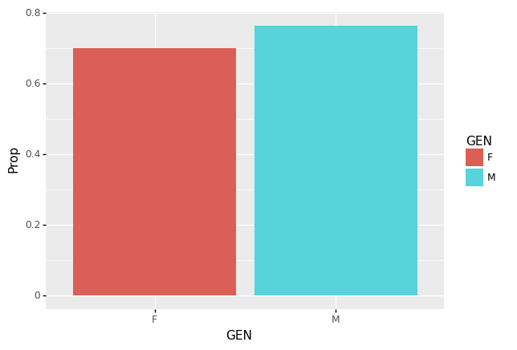

```python
ggplot(tb.query('STATE=="PASS"'))+geom_bar(aes(x='GEN',y='Prop',fill='GEN'),position='dodge',stat='identity')
```

`-` 남자의 합격률이 더 높다 $\to$ 성차별이 있어보인다(?)

#### 시각화2: 학과별비교

`-` 학과별로 비교하자.

```python
df
```

|  | DEP | STATE | GEN | COUNT |
| --- | --- | --- | --- | --- |
| 0 | A1 | PASS | M | 1 |
| 1 | A1 | FAIL | M | 9 |
| 2 | A2 | PASS | M | 2 |
| 3 | A2 | FAIL | M | 8 |
| 4 | B1 | PASS | M | 80 |
| 5 | B1 | FAIL | M | 20 |
| 6 | B2 | PASS | M | 85 |
| 7 | B2 | FAIL | M | 15 |
| 8 | A1 | PASS | F | 5 |
| 9 | A1 | FAIL | F | 5 |
| 10 | A2 | PASS | F | 5 |
| 11 | A2 | FAIL | F | 5 |
| 12 | B1 | PASS | F | 9 |
| 13 | B1 | FAIL | F | 1 |
| 14 | B2 | PASS | F | 9 |
| 15 | B2 | FAIL | F | 1 |

```python
df.groupby(['GEN','DEP','STATE']).agg({'COUNT':sum})
```

| GEN | DEP | STATE | COUNT |
| --- | --- | --- | --- |
| F | A1 | FAIL | 5 |
|  |  | PASS | 5 |
|  | A2 | FAIL | 5 |
|  |  | PASS | 5 |
|  | B1 | FAIL | 1 |
|  |  | PASS | 9 |
|  | B2 | FAIL | 1 |
|  |  | PASS | 9 |
| M | A1 | FAIL | 9 |
|  |  | PASS | 1 |
|  | A2 | FAIL | 8 |
|  |  | PASS | 2 |
|  | B1 | FAIL | 20 |
|  |  | PASS | 80 |
|  | B2 | FAIL | 15 |
|  |  | PASS | 85 |

```python
df.groupby(['GEN','STATE','DEP']).agg({'COUNT':sum}).reset_index()
```

|  | GEN | STATE | DEP | COUNT |
| --- | --- | --- | --- | --- |
| 0 | F | FAIL | A1 | 5 |
| 1 | F | FAIL | A2 | 5 |
| 2 | F | FAIL | B1 | 1 |
| 3 | F | FAIL | B2 | 1 |
| 4 | F | PASS | A1 | 5 |
| 5 | F | PASS | A2 | 5 |
| 6 | F | PASS | B1 | 9 |
| 7 | F | PASS | B2 | 9 |
| 8 | M | FAIL | A1 | 9 |
| 9 | M | FAIL | A2 | 8 |
| 10 | M | FAIL | B1 | 20 |
| 11 | M | FAIL | B2 | 15 |
| 12 | M | PASS | A1 | 1 |
| 13 | M | PASS | A2 | 2 |
| 14 | M | PASS | B1 | 80 |
| 15 | M | PASS | B2 | 85 |

```python
df.groupby(['GEN','DEP']).agg({'COUNT':sum}).reset_index().rename(columns={'COUNT':'SUM'})
```

|  | GEN | DEP | SUM |
| --- | --- | --- | --- |
| 0 | F | A1 | 10 |
| 1 | F | A2 | 10 |
| 2 | F | B1 | 10 |
| 3 | F | B2 | 10 |
| 4 | M | A1 | 10 |
| 5 | M | A2 | 10 |
| 6 | M | B1 | 100 |
| 7 | M | B2 | 100 |

```python
tb=df.groupby(['GEN','STATE','DEP']).agg({'COUNT':sum}).reset_index().merge(df.groupby(['GEN','DEP']).agg({'COUNT':sum}).reset_index().rename(columns={'COUNT':'SUM'}))
tb
```

|  | GEN | STATE | DEP | COUNT | SUM |
| --- | --- | --- | --- | --- | --- |
| 0 | F | FAIL | A1 | 5 | 10 |
| 1 | F | PASS | A1 | 5 | 10 |
| 2 | F | FAIL | A2 | 5 | 10 |
| 3 | F | PASS | A2 | 5 | 10 |
| 4 | F | FAIL | B1 | 1 | 10 |
| 5 | F | PASS | B1 | 9 | 10 |
| 6 | F | FAIL | B2 | 1 | 10 |
| 7 | F | PASS | B2 | 9 | 10 |
| 8 | M | FAIL | A1 | 9 | 10 |
| 9 | M | PASS | A1 | 1 | 10 |
| 10 | M | FAIL | A2 | 8 | 10 |
| 11 | M | PASS | A2 | 2 | 10 |
| 12 | M | FAIL | B1 | 20 | 100 |
| 13 | M | PASS | B1 | 80 | 100 |
| 14 | M | FAIL | B2 | 15 | 100 |
| 15 | M | PASS | B2 | 85 | 100 |

```python
tb['Prop']=tb.COUNT/tb.SUM
tb
```

|  | GEN | STATE | DEP | COUNT | SUM | Prop |
| --- | --- | --- | --- | --- | --- | --- |
| 0 | F | FAIL | A1 | 5 | 10 | 0.50 |
| 1 | F | PASS | A1 | 5 | 10 | 0.50 |
| 2 | F | FAIL | A2 | 5 | 10 | 0.50 |
| 3 | F | PASS | A2 | 5 | 10 | 0.50 |
| 4 | F | FAIL | B1 | 1 | 10 | 0.10 |
| 5 | F | PASS | B1 | 9 | 10 | 0.90 |
| 6 | F | FAIL | B2 | 1 | 10 | 0.10 |
| 7 | F | PASS | B2 | 9 | 10 | 0.90 |
| 8 | M | FAIL | A1 | 9 | 10 | 0.90 |
| 9 | M | PASS | A1 | 1 | 10 | 0.10 |
| 10 | M | FAIL | A2 | 8 | 10 | 0.80 |
| 11 | M | PASS | A2 | 2 | 10 | 0.20 |
| 12 | M | FAIL | B1 | 20 | 100 | 0.20 |
| 13 | M | PASS | B1 | 80 | 100 | 0.80 |
| 14 | M | FAIL | B2 | 15 | 100 | 0.15 |
| 15 | M | PASS | B2 | 85 | 100 | 0.85 |

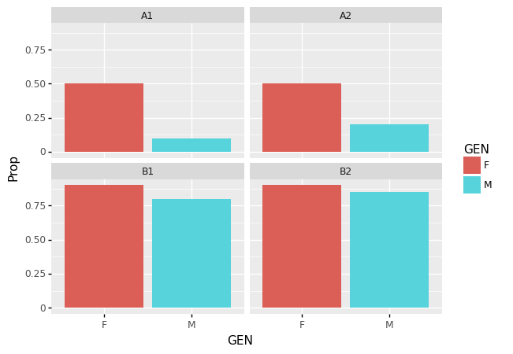

```python
ggplot(tb.query('STATE=="PASS"'))+geom_bar(aes(x='GEN',y='Prop',fill='GEN'),position='dodge',stat='identity')+facet_wrap("DEP")
```

`-` 모든학과에서 여성의 합격률이 더 높다.

### join 벼락치기

`-` 공통된열이 있으면 그 열을 기준으로 두 df를 합칠수 있다.

```python
_df1
```

|  | GEN | STATE | COUNT |
| --- | --- | --- | --- |
| 0 | F | FAIL | 12 |
| 1 | F | PASS | 28 |
| 2 | M | FAIL | 52 |
| 3 | M | PASS | 168 |

```python
_df2
```

|  | GEN | SUM |
| --- | --- | --- |
| 0 | F | 40 |
| 1 | M | 220 |

`-` 공통된열은 GEN

```python
_df1.merge(_df2)
```

|  | GEN | STATE | COUNT | SUM |
| --- | --- | --- | --- | --- |
| 0 | F | FAIL | 12 | 40 |
| 1 | F | PASS | 28 | 40 |
| 2 | M | FAIL | 52 | 220 |
| 3 | M | PASS | 168 | 220 |

```python
_df2.merge(_df1)
```

|  | GEN | SUM | STATE | COUNT |
| --- | --- | --- | --- | --- |
| 0 | F | 40 | FAIL | 12 |
| 1 | F | 40 | PASS | 28 |
| 2 | M | 220 | FAIL | 52 |
| 3 | M | 220 | PASS | 168 |

```python
pd.merge(_df1,_df2)
```

|  | GEN | STATE | COUNT | SUM |
| --- | --- | --- | --- | --- |
| 0 | F | FAIL | 12 | 40 |
| 1 | F | PASS | 28 | 40 |
| 2 | M | FAIL | 52 | 220 |
| 3 | M | PASS | 168 | 220 |